# OSMI Analysis Demographics Markdown

### 5.2.5 Plotting Anonymity Protection

The following variable “anon_protect” indicates whether respondents remain anonymous if they chose to utilize mental health and/or substance abuse treatment resources provided by their employers.

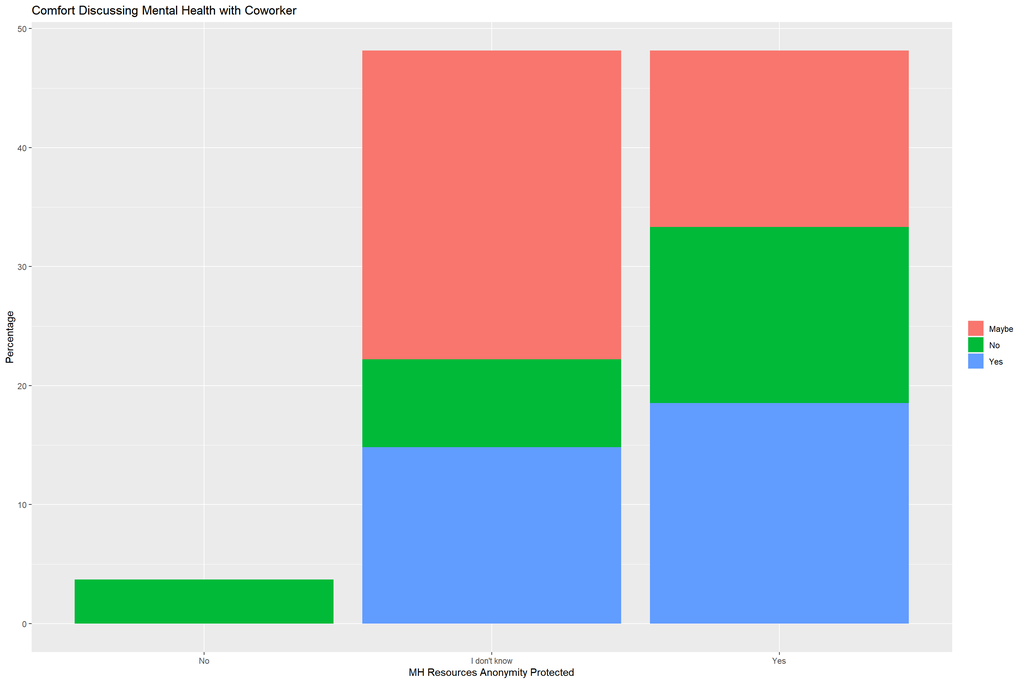

```r
osmi_comfort$anon_protect <- factor(osmi_comfort$anon_protect, order = TRUE,
                                           levels = c("No", "I don't know", "Yes"))

osmi_anon_com_cow <- osmi_comfort %>%
  drop_na(anon_protect) %>%
  ggplot(aes(x = anon_protect, y = after_stat(100*count/sum(count)), fill = comfort_coworker)) +
  geom_bar() +
  labs(x = "MH Resources Anonymity Protected", y = "Percentage", fill = "",
       title = "Comfort Discussing Mental Health with Coworker")
osmi_anon_com_cow
```

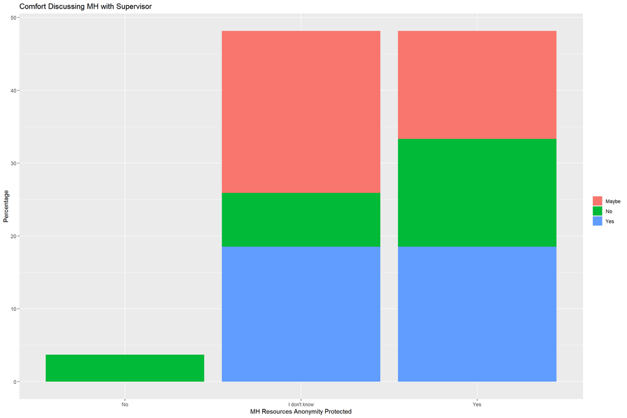

```r
osmi_anon_sup <- osmi_comfort %>%
  drop_na(anon_protect) %>%
  ggplot(aes(x = anon_protect, y = after_stat(100*count/sum(count)), fill = comfort_supervisor)) +
  geom_bar() +
  labs(x = "MH Resources Anonymity Protected", y = "Percentage", fill = "",
       title = "Comfort Discussing MH with Supervisor")
osmi_anon_sup
```

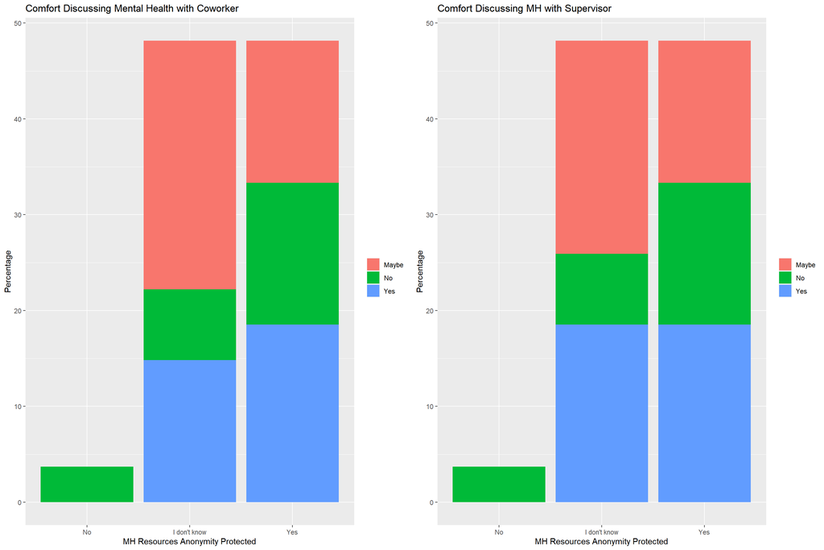

```r
grid.arrange(osmi_anon_com_cow,
             osmi_anon_sup,
             ncol = 2)
```

The data yielded trends that were similar to that of previous sections. Respondents who did not have their anonymity protected when seeking mental health resources were less likely to be comfortable discussing mental health topics with their coworkers or supervisors, but the opposite was true for respondents whose companies protected their identities when seeking mental healthcare.

### 5.2.6 Plotting Perceived Difficulty Obtaining Mental Health Leave

The following variable, “mh_leave_difficulty” indicates whether respondents perceive obtaining mental health leave to be a trivial or difficult task. Unlike the previous variables, “mh_leave_difficulty” is a true ordinal variable, consisting of a range of answers ranging from “Very easy” to “Difficult” for a total of 5 different responses.

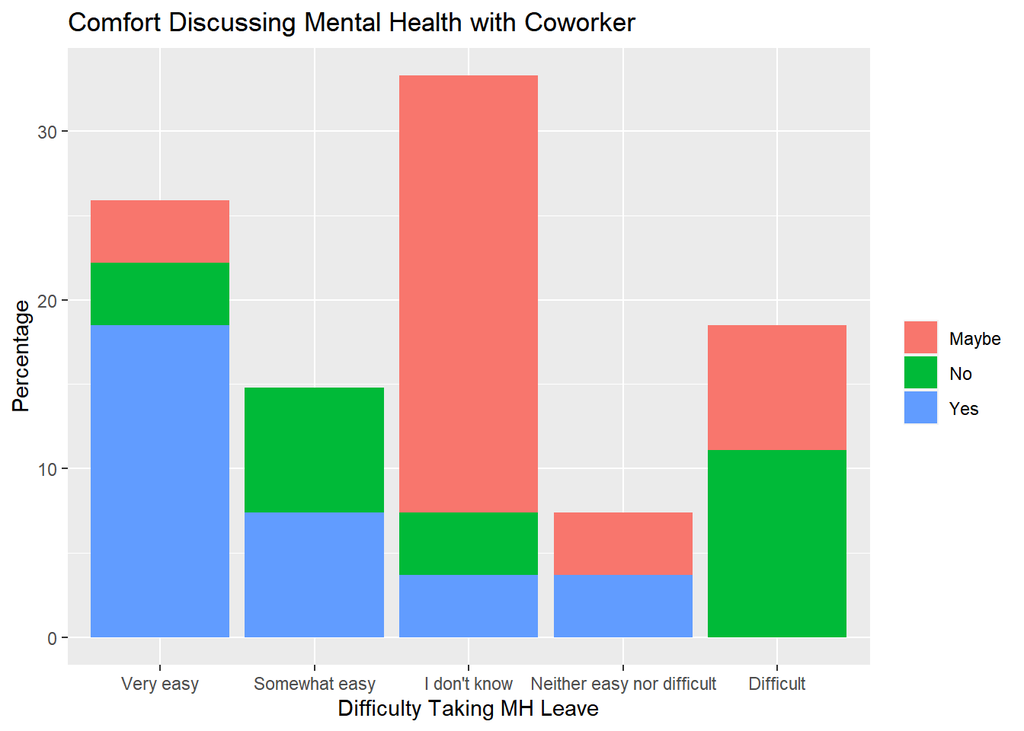

```r
osmi_comfort$mh_leave_difficulty <- factor(osmi_comfort$mh_leave_difficulty, order = TRUE,
                                           levels = c("Very easy", "Somewhat easy", "I don't know",
                                                      "Neither easy nor difficult", "Somewhat difficult", "Difficult"))

osmi_lea_com_cow <- osmi_comfort %>%
  drop_na(mh_leave_difficulty) %>%
  ggplot(aes(x = mh_leave_difficulty, y = after_stat(100*count/sum(count)), fill = comfort_coworker)) +
  geom_bar() +
  labs(x = "Difficulty Taking MH Leave", y = "Percentage", fill = "", title = "Comfort Discussing Mental Health with Coworker")
osmi_lea_com_cow
```

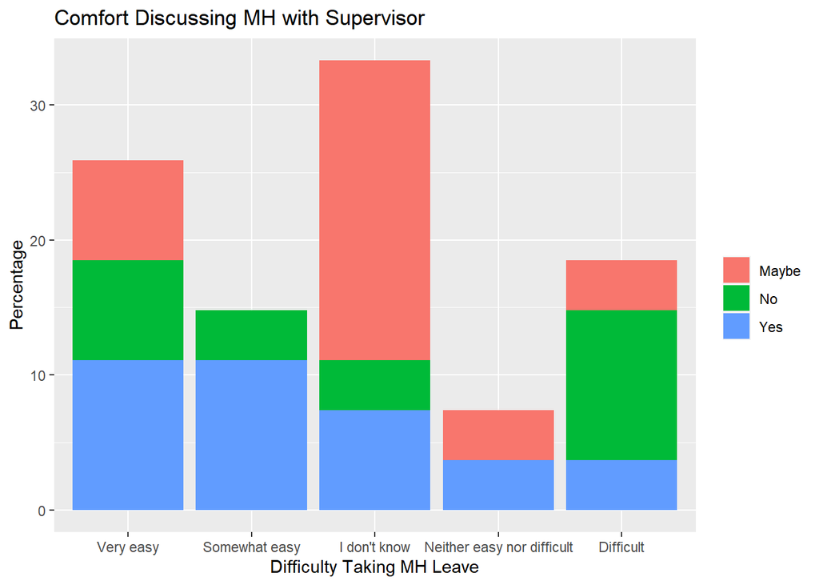

```r
osmi_lea_sup <- osmi_comfort %>%
  drop_na(mh_leave_difficulty) %>%
  ggplot(aes(x = mh_leave_difficulty, y = after_stat(100*count/sum(count)), fill = comfort_supervisor)) +
  geom_bar() +
  labs(x = "Difficulty Taking MH Leave", y = "Percentage", fill = "", title = "Comfort Discussing MH with Supervisor")
osmi_lea_sup
```

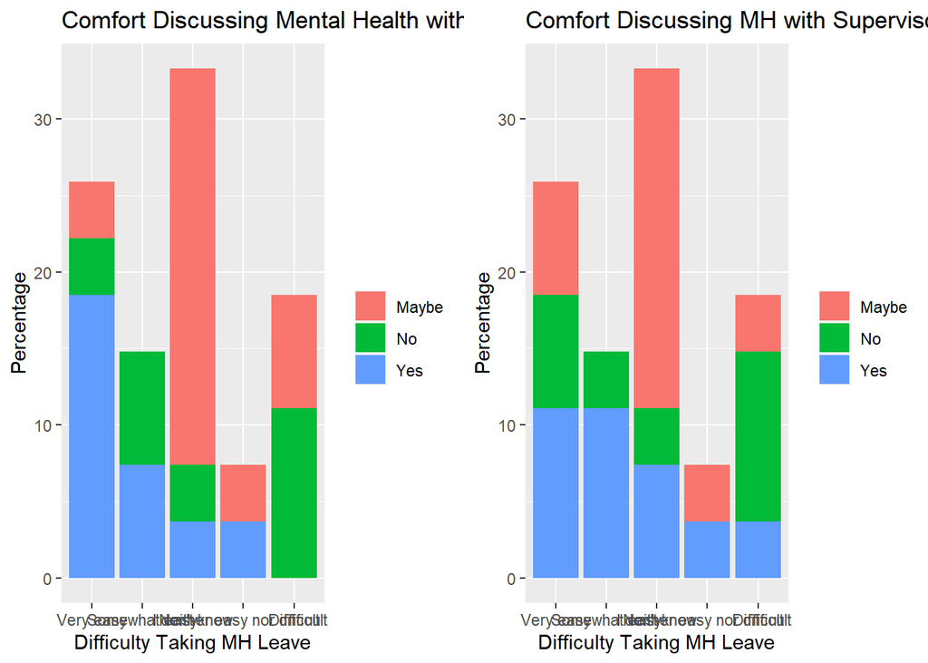

```r
grid.arrange(osmi_lea_com_cow,
             osmi_lea_sup,
             ncol = 2)
```

The data reflects a trend similar to the other workplace variables mentioned previously. The proportion of respondents comfortable discussing mental health issues with their colleagues (labelled blue in the plot) is significantly higher when difficultly taking mental health leave is perceived to be easier, and is significantly lower when taking leave is believed to be more difficult. An observation here is that with respondents who chose “I don’t know”, a majority of them are unsure about whether they are comfortable discussing mental health (labelled pink); more importantly, the proportion of respondents who picked “maybe” as to their comfort levels in this group are significantly larger than the rest of the other answers.

## 5.3 Summary of Plots

As with the previous Sections, we can use *grid.arrange* to combine all the plots together for presentation purposes.

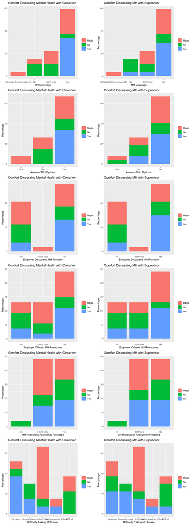

```r
grid.arrange(osmi_cov_com_cow, osmi_cov_sup,
             osmi_opt_com_cow, osmi_opt_sup,
             osmi_empdis_com_cow, osmi_empdis_sup,
             osmi_resoff_com_cow, osmi_resoff_sup,
             osmi_anon_com_cow, osmi_anon_sup,
             osmi_lea_com_cow, osmi_lea_sup,
             ncol = 2)
```

## 5.4 Discussion

The data visualizations from this Section provide the most compelling picture about the relationship between workplace conditions and mental health related factors so far. Workplace variables, intended to indicate the degree to which tech companies value and provide mental health support for their employees, all appear to suggest a common trend with respect to interpersonal comfort discussing mental health among coworkers and supervisors. Specifically, whether companies provided mental health coverage; made employees explicitly aware of mental health options they could utilize; discussed mental health in a formal context; offered mental health resources to their employees; ensured the confidentiality of employees accessing mental health resources; and ensured employees did not find it difficult to obtain leave for mental health reasons; all indicate a pattern in respondents’ responses with respect to their comfort in engaging in mental health discussion in the workplace setting. As the mental health resource in question became more accessible, respondents were more likely to be comfortable talking about mental health with coworkers and/or supervisors.

An interesting observation of the data visualizations is that there appears to be a pattern regarding undecided responses. In most of these plots, respondents who answered “I don’t know” to any of the workplace variables (i.e., x-axis variable) were significantly more likely to answer “Maybe” (labelled pink on the plots) when asked how comfortable they were discussing mental health issues in the workplace compared to the other response groups. Combined with the general trend that was observed, this suggests that employees benefit from human resources teams taking the time to explain, in-depth, the mental health resources that are available to employees and how to access them.

The two main findings from this Section suggests that what mental health resources are available, as well as how employers communicate the availability of these resources to their employees, may impact whether those working in the tech industry are more comfortable discussing mental health topics with their peers or superiors, and perhaps consequently whether they opt to seek mental health treatment. In other words, a work culture that promotes openness with respect to mental health may lead to a more (mentally) healthier workforce.

A limitation of the data is that in most of these plots, there is at least one group with which there was a very small number of responses. For example, in the “MH Resources Anonymity Protected” plots, less than 5% of respondents answered “No”. Using *nrow*, we can verify that there are a total of 27 responses in the data subset “osmi_comfort”; therefore, the aforementioned “No” responses accounts for only 1-2 respondents out of the entire sample, and is prone to anomalous results. Consequently, this weakens the reliability of our trend analyses above. Future research should aim to replicate these findings with a larger sample, before using correlational analyses to delve further into any patterns that may exist.

# 6. Conclusion and Recommendations

## 6.1 Summary of Findings

The following data analysis aimed to explore the responses gathered from the 2021 OSMI Mental Health in Tech Survey to identify trends and observations with regards to mental health in the workplace as well as the prevalence of mental health disorders in said industry’s workforce. The exploratory nature of this analysis meant that a broader range of variables were covered in analysis and visualization, and the findings here are meant to provide preliminary information as a basis for future research objectives. The analysis was limited to American respondents only, yielding a sample size of 27 participants. It should be noted that the 2021 dataset had the least amount of data collected (n = 131) in OSMI’s history, and thus resulted in a smaller-than-usual sample to analyze.

Analysis of the demographic data revealed that most respondents held tech-related roles at small-sized tech companies consisting of 25 or less employees. The majority of respondents were aged between 30-40 years old, and their gender identity were almost equally divided between males and females. Most respondents identified as Caucasian, a very slim proportion of respondents identified as multi-racial, and the rest of the sample consisted of Asian-identifying individuals. Respondents came from 16 different states, with a noticeable concentration of respondents residing in California.

Analysis of data related to the prevalence of mental health disorders revealed surprising trends in the sample. Over half of respondents reported currently or previously having been diagnosed with a mental health disorder. Of those diagnosed, over three quarters indicated having comorbid (i.e., multiple) mental health disorders simultaneously, with the rest indicating having a mood, psychotic, or stress disorder. The data suggests that prevalence rates of mental health disorders are exceptionally high in the tech industry as compared to the general public, such that disorders in tech companies are often the norm more often than not.

Analysis of data related to workplace related effects of mental health problems revealed a trend towards the perception that mental health disorders are more disruptive to work performance when left untreated, hinting at the importance of mental healthcare in workforce productivity. About 1 in 4 respondents were openly identified as struggling with a mental health disorder in their workplace, yet the majority of them believe that being identified as such did not have an impact on their careers. Despite this, most respondents felt that the tech industry and their employers provided only a moderate or weak level of mental health suppport, suggesting that there is room for improvement with regards to mental healthcare in tech companies. Lastly, there appeared to be no trend with regards to badly versus well handled mental health issues (i.e., witnessing a badly handled mental health issue does not appear to correlate with a reduction in observations of well handled ones), and the distribution of responses combined with the ambiguity of interpreting “unsure” responses make it difficult to make any remarks on said data.

Perhaps the most interesting findings were that of variables related to a company’s mental healthcare comprehensiveness and how it was related to respondents’ comfort in discussing mental health topics with their coworkers and/or supervisors. All the “workplace variables” plotted indicated a potential trend in respondents’ comfortableness in discussing mental health issues with their colleagues; as mental health resources (e.g., mental health medical coverage) became more available and accessible (i.e., employees do not perceive significant difficulty in using such resources), respondents appeared more likely to be comfortable in engaging their colleagues with mental health topics. Being more open to employees about mental health issues (e.g., hosting mental health campaigns or talking about mental health in formal communications) also appears to help.

A significant limitation of the data is the small sample size. With a sample size of only 27 responses, this dataset does not meet the minimum criteria to satisfy the assumptions of the [Central Limit Theorem](https://en.wikipedia.org/wiki/Central_limit_theorem). As with most research in the social sciences, we assume that the data should usually be distributed normally. Because of this, this makes the reliability of our findings and conclusions questionable, and the small size by nature lends great uncertainty as to whether the data represents the population in question.

Another limitation is that some demographics were not represented in this dataset. For example, the dataset did not have any respondents who identified as African-American and/or Black. As with the previous limitation, a replicated study with a significantly larger sample size ought to resolve this issue, and oversampling methods can be utilized if necessary.

## 6.2 Recommendations

Based on our data analysis, several recommendations can be made regarding research and applied policy changes. First and foremost, the small sample size of our dataset means that a replication of this study is highly recommended before implementing any of the recommendations that will be listed out below. Replicating the survey with a larger sample size will improve the reliability and validity of our data and lend greater support to our findings and conclusions. It will also allow us to determine whether any of our observations were due to anomalous results.

The strongest trend indicated by our data is that one’s level of comfort discussing mental health may be influenced by the level of mental health support that is provided by employers. We recommend that future research can focus into this area, such as utilizing longitudinal research methods to determine whether implementing mental health awareness programs and including mental health coverage in medical benefits for employees can improve the well-being of workers in the tech industry. Since our findings also suggested that employees perceive mental health disorders to disrupt productivity when left untreated, another line of related research would be to determine the improvement (if it exists) in work performance of employees with mental health disorders after a period of mental health treatment. Together, these lines of research may allow us to posit whether providing mental health support to employees, just like physical health support, can improve the health of not just workers, but also improve overall work efficiency within a tech company.

Prevalence data suggests that the occurrence of mental health disorders in the tech industry may be significantly higher than of that seen in the general public. Therefore, future research could investigate what unique factors in said field (e.g., work setting, work hours, nature of work) may be influencing the higher rate of mental disorders observed. The findings from such research could inform clinical personnel (e.g., psychologists) about specific signs, symptoms, and/or lifestyle factors that may be maintaining one’s mental disorder, allowing for more effective treatment.

Finally, future research could benefit from use of regression analyses to identify which variables may predict, and to what extent, the occurrence of a mental health disorder. For example, using a [generalized linear model](https://en.wikipedia.org/wiki/Generalized_linear_model) to provide further insight into what proportion of variance can be accounted for by the specific variables inputted, and which variables may have greater power in explaining for the observed phenomena.

With respect to policy or applied recommendations, several suggestions can be made and would be supported by future research topics mentioned above. First, we recommend tech companies to be more transparent to employees about mental health issues. Discussing mental health topics in a formal setting and promoting mental health awareness in the workplace may make employees more educated and less hesitant in seeking treatment or help when required, rather than hiding such issues from their employers which could potentially hinder productivity and treatment. Second, employers should be more inclusive in employees’ medical benefits (i.e., providing comprehensive physical **and** mental health coverage), as it can indirectly improve the company’s profitability in the long run via improved workforce efficiency. Finally, employers should take care in handling mental health issues in the workplace, as how such issues are handled may affect employees’ willingness to divulge their mental health problems to employers and/or treatment providers, prolonging their suffering; that said, there is less data to support this recommendation and observation and/or data collection by human resource teams may lend greater insight into the effectiveness of this policy recommendation.